# DS Minor: Lab 02 – Centrality measures and community detection Intro

На предыдущем занятии мы поговорили о сетях в целом и посмотрели на свои сети друзей ВК.

### Рисование графа

В пакете `igraph` много параметров для визуализации графов. Более подробно можно посмотреть в `?igraph.plotting`.

Загрузим опять граф про семьи Флоренции (см. предыдущее занятие)

```r
library(readr)
library(igraph)
adjFlorence <- read_csv("~/shared/minor2_2018/2-tm-net/lab01-netIntro/florentineFamily.csv")
rownames(adjFlorence) <- names(adjFlorence)
adjFlorence <- as.matrix.data.frame(adjFlorence)

florentine <- graph_from_adjacency_matrix(adjmatrix = adjFlorence, mode = "undirected")
```

Можно менять цвета, размеры, подписи, фон и т.д., чтобы получить именно тот вид графа, что нужен. Существует два способа определения этих параметров.

Первый – указать их в функции `plot`:

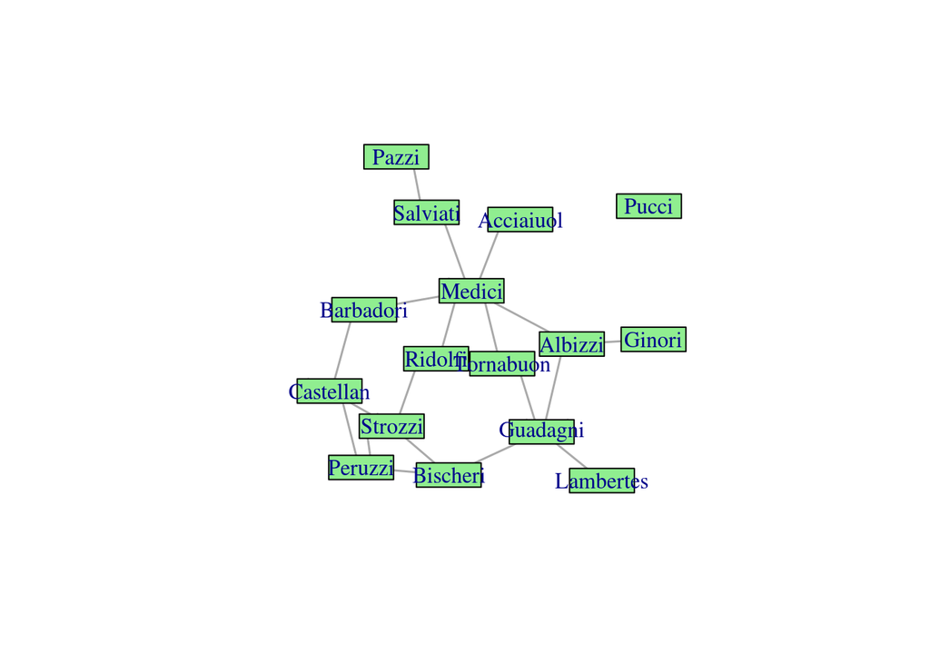

```r
plot(florentine,
     vertex.color = "lightgreen",
     vertex.size = 40,
     vertex.shape = "rectangle",
     edge.width = 1.5)
```

Второй способ – задать нужные значения как свойства вершин или ребер.

```r
V(florentine)$name
```

```
##  [1] "Acciaiuol" "Albizzi"   "Barbadori" "Bischeri"  "Castellan"
##  [6] "Ginori"    "Guadagni"  "Lambertes" "Medici"    "Pazzi"
## [11] "Peruzzi"   "Pucci"     "Ridolfi"   "Salviati"  "Strozzi"
## [16] "Tornabuon"
```

```r
#проверим до
V(florentine)$color
```

[output not shown]

```r
V(florentine)$color = c(rep("lightblue",8),rep("red",8))

#проверим после
V(florentine)$color
```

```
##  [1] "lightblue" "lightblue" "lightblue" "lightblue" "lightblue"
##  [6] "lightblue" "lightblue" "lightblue" "red"       "red"
## [11] "red"       "red"       "red"       "red"       "red"
## [16] "red"
```

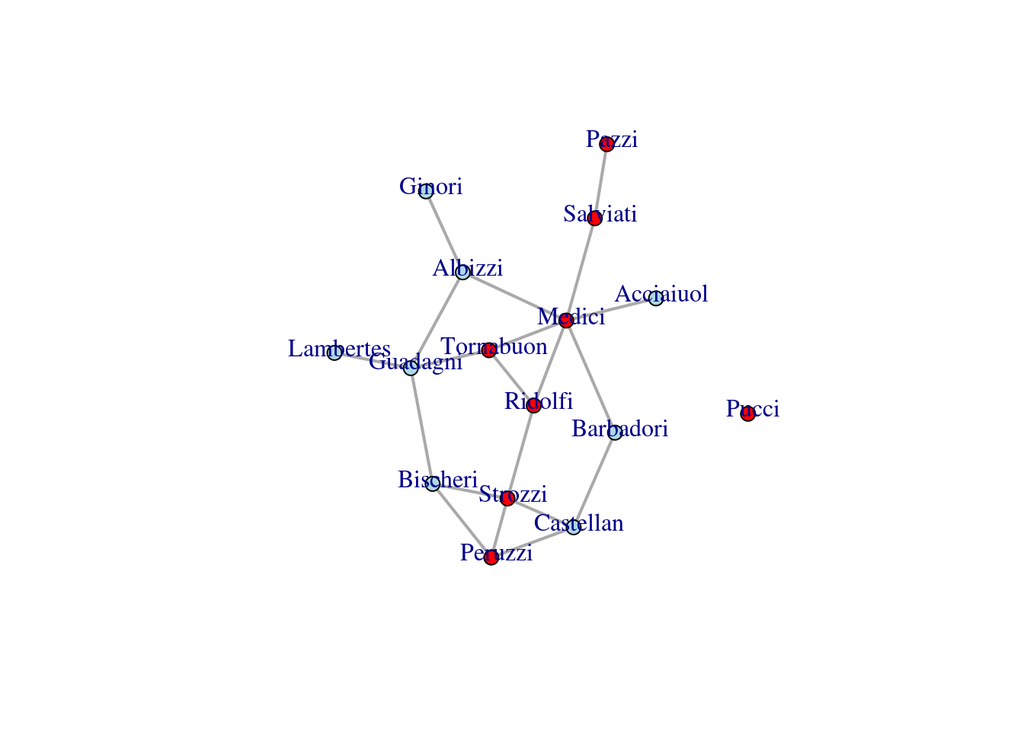

```r
V(florentine)$size = 7
V(florentine)$label.dist = 0.5 # labels outside the circles
E(florentine)$width = 2
plot(florentine)
```

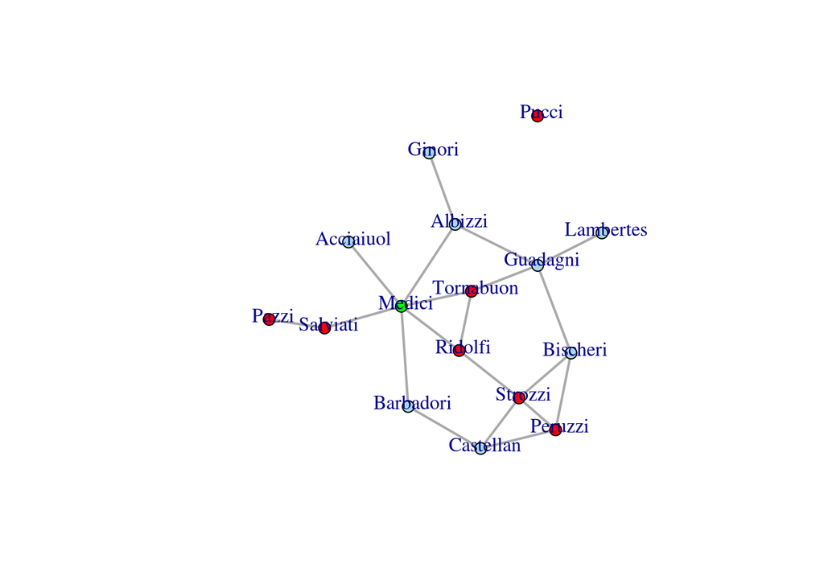

```r
#
V(florentine)$color[9] = "green"
plot(florentine)
```

Еще один параметр визуализации – укладка (layout)

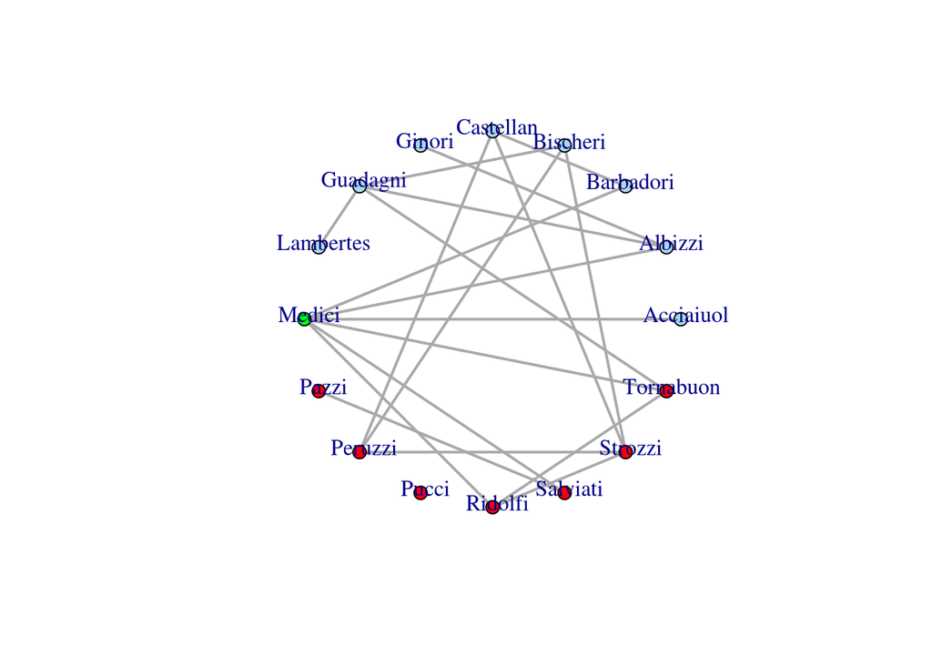

```r
plot(florentine, layout = layout.circle)
```

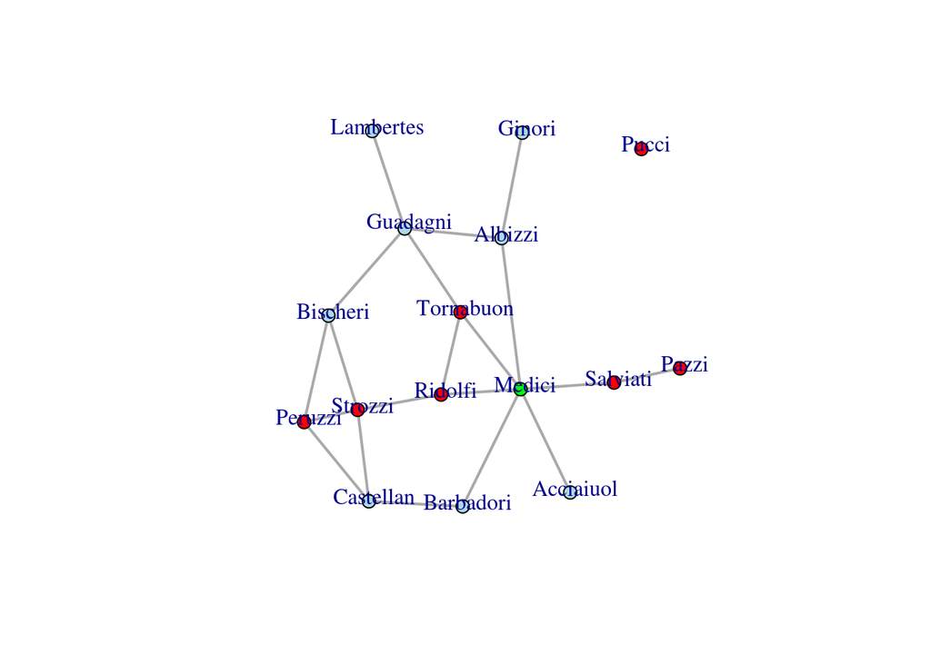

```r
plot(florentine, layout = layout.fruchterman.reingold)
```

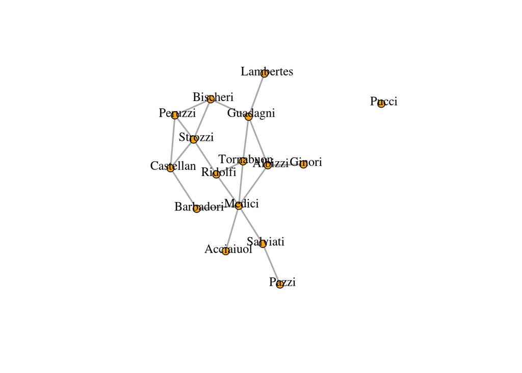

```r
plot(florentine, layout = layout.kamada.kawai,
     vertex.color = "orange",
     vertex.label.color = "black")
```

### Меры центральности

Не все вершины в сети однаково важны – какие-то могут быть более влиятельны, какие-то менее. В разных задачах “важность” может пониматься по-разному.

Например, можно считать в сети друзей важнее того из них, у кого больше друзей (“чем больше связей, тем лучше”). Такой показатель называется **степенью (degree)**.

Рассмотрим на небольшом примере социальной сети - сети клуба карате (Zachary carate club).

Загрузим данные из пакета igraphdata (здесь цвет – вручную заданные группы)

```r
library(igraph)
library(igraphdata)

data(karate) # loading network from package
```

Посчитаем степень узла

```r
V(karate)
```

```
## + 34/34 vertices, named, from 4b458a1:
##  [1] Mr Hi    Actor 2  Actor 3  Actor 4  Actor 5  Actor 6  Actor 7
##  [8] Actor 8  Actor 9  Actor 10 Actor 11 Actor 12 Actor 13 Actor 14
## [15] Actor 15 Actor 16 Actor 17 Actor 18 Actor 19 Actor 20 Actor 21
## [22] Actor 22 Actor 23 Actor 24 Actor 25 Actor 26 Actor 27 Actor 28
## [29] Actor 29 Actor 30 Actor 31 Actor 32 Actor 33 John A
```

```r
degree(karate)
```

```
##    Mr Hi  Actor 2  Actor 3  Actor 4  Actor 5  Actor 6  Actor 7  Actor 8
##       16        9       10        6        3        4        4        4
##  Actor 9 Actor 10 Actor 11 Actor 12 Actor 13 Actor 14 Actor 15 Actor 16
##        5        2        3        1        2        5        2        2
## Actor 17 Actor 18 Actor 19 Actor 20 Actor 21 Actor 22 Actor 23 Actor 24
##        2        2        2        3        2        2        2        5
## Actor 25 Actor 26 Actor 27 Actor 28 Actor 29 Actor 30 Actor 31 Actor 32
##        3        3        2        4        3        4        4        6
## Actor 33   John A
##       12       17
```

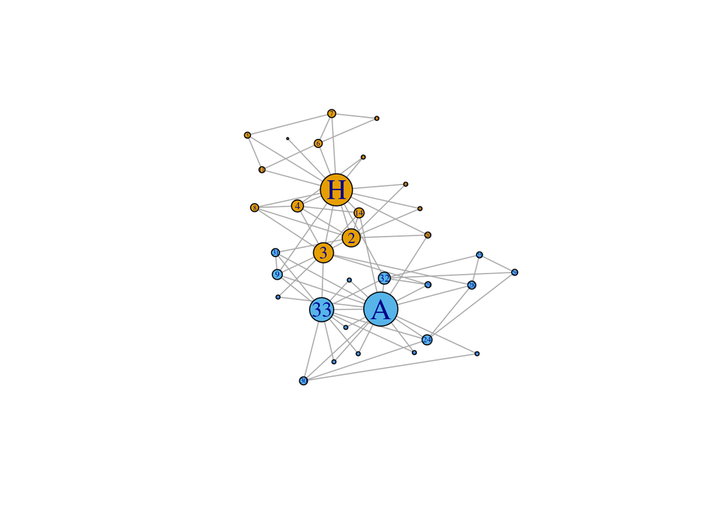

```r
plot(karate,
     vertex.size = degree(karate)*1.5,
     vertex.label.cex = degree(karate)/10,
     layout = layout.davidson.harel)
```

Еще одним показателем важности является **центральность по посредничеству, битвинность (betweenness)**. В этом случае важны вершины, которые являются посредниками между группами, находятся на “выгодном” месте.

```r
betweenness(karate)
```

```
##      Mr Hi    Actor 2    Actor 3    Actor 4    Actor 5    Actor 6
## 250.150000  33.800000  36.650000   1.333333   0.500000  15.500000
##    Actor 7    Actor 8    Actor 9   Actor 10   Actor 11   Actor 12
##  15.500000   0.000000  13.100000   7.283333   0.500000   0.000000
##   Actor 13   Actor 14   Actor 15   Actor 16   Actor 17   Actor 18
##   0.000000   1.200000   0.000000   0.000000   0.000000  16.100000
##   Actor 19   Actor 20   Actor 21   Actor 22   Actor 23   Actor 24
##   3.000000 127.066667   0.000000   0.000000   0.000000   1.000000
##   Actor 25   Actor 26   Actor 27   Actor 28   Actor 29   Actor 30
##  33.833333   0.500000   0.000000   6.500000  10.100000   0.000000
##   Actor 31   Actor 32   Actor 33     John A
##   3.000000  66.333333  38.133333 209.500000
```

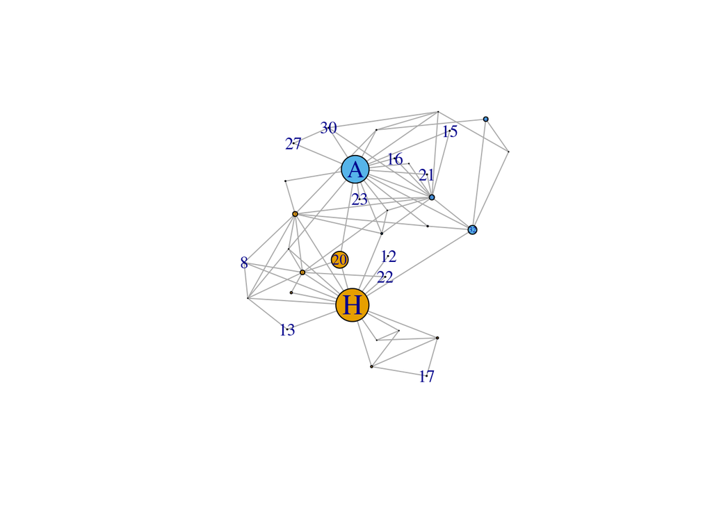

```r
plot(karate,
     vertex.size = betweenness(karate)/10,
     vertex.label.cex = betweenness(karate)/150,
     layout = layout.davidson.harel)
```

Если нам интересны вершины с наиболее короткими путями до остальных (т.е. наиболее близкие к остальным), то рассматривается **центральность по близости (closeness)**.

```r
closeness(karate)
```

```
##       Mr Hi     Actor 2     Actor 3     Actor 4     Actor 5     Actor 6
## 0.007575758 0.005494505 0.005847953 0.005235602 0.004587156 0.004587156
##     Actor 7     Actor 8     Actor 9    Actor 10    Actor 11    Actor 12
## 0.004629630 0.005494505 0.005882353 0.005494505 0.005291005 0.004405286
##    Actor 13    Actor 14    Actor 15    Actor 16    Actor 17    Actor 18
## 0.006134969 0.005747126 0.005154639 0.004098361 0.003267974 0.005780347
##    Actor 19    Actor 20    Actor 21    Actor 22    Actor 23    Actor 24
## 0.005586592 0.007246377 0.006134969 0.005319149 0.004716981 0.004149378
##    Actor 25    Actor 26    Actor 27    Actor 28    Actor 29    Actor 30
## 0.004694836 0.003690037 0.005076142 0.004629630 0.006097561 0.005263158
##    Actor 31    Actor 32    Actor 33      John A
## 0.004878049 0.006097561 0.005952381 0.007575758
```

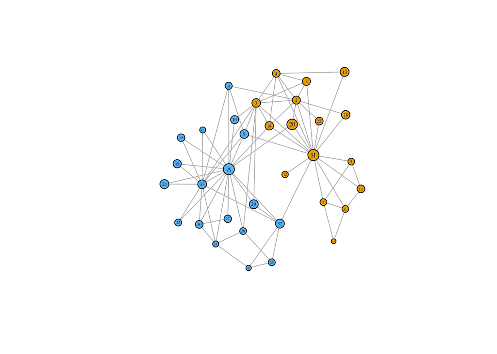

[figure not shown]

```r
plot(karate,
     vertex.size = closeness(karate)*1500,
     vertex.label.cex = closeness(karate)*70,
     layout = layout.davidson.harel)
```

### Выявление сообществ (community detection)

Основная идея выделения сообществ – члены сообщества должны быть больше похожи друг на друга, чем на участников других сообществ (другими словами, число связей между членами одного сообщества должно быть больше, чем число связей между сообществами).

Метод **edge betweenness**: иерархический метод, состоящий в последовательном удалении связей в порядке убывания показателей битвинности ребер (edge betweenness scores), то есть числа кратчайших путей, проходящих по рассматриваемому ребру.

```r
ebcommune <- edge.betweenness.community(karate)
membership(ebcommune) ## assigning nodes to communities
```

```
##    Mr Hi  Actor 2  Actor 3  Actor 4  Actor 5  Actor 6  Actor 7  Actor 8
##        1        1        2        1        3        3        3        1
##  Actor 9 Actor 10 Actor 11 Actor 12 Actor 13 Actor 14 Actor 15 Actor 16
##        4        2        3        1        1        2        4        4
## Actor 17 Actor 18 Actor 19 Actor 20 Actor 21 Actor 22 Actor 23 Actor 24
##        3        1        4        1        4        1        4        5
## Actor 25 Actor 26 Actor 27 Actor 28 Actor 29 Actor 30 Actor 31 Actor 32
##        5        5        6        5        2        6        4        4
## Actor 33   John A
##        4        4
```

```r
modularity(ebcommune)
```

```
## [1] 0.345299
```

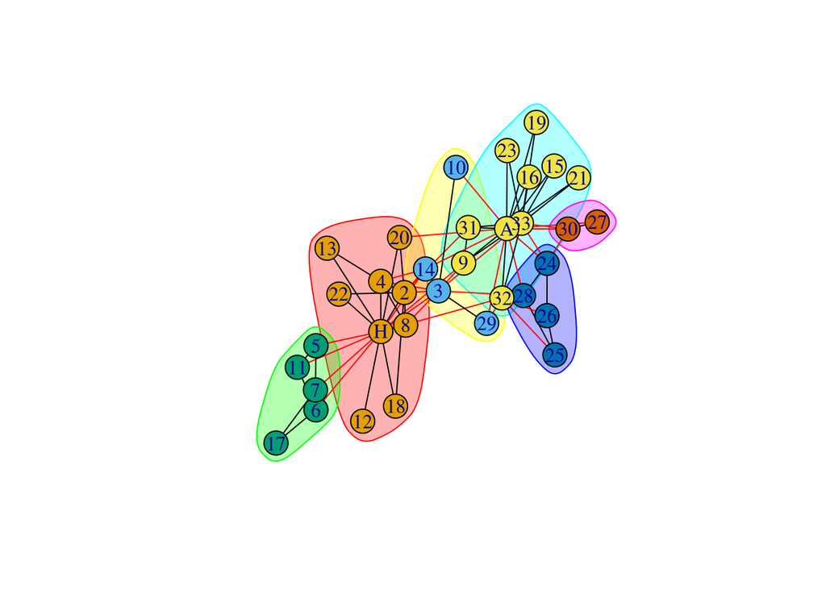

```r
plot(ebcommune, karate)
```

Сколько групп получилось?

#### Другие алгоримы

- **Fast-Greedy**: иерархический подход. Первоначально каждая вершина представляет собой отдельное сообщество. Сообщества объединяются таким образом, чтобы это привело к наибольшему возрастанию модулярности. Останавливаемся, когда нет следующего шага, увеличивающего модулярность. Посмотрим на примере семей Флоренции

```r
fgcommune <- fastgreedy.community(florentine)
membership(fgcommune) ## assigning nodes to communities
```

```
## Acciaiuol   Albizzi Barbadori  Bischeri Castellan    Ginori  Guadagni
##         1         2         3         3         3         2         2
## Lambertes    Medici     Pazzi   Peruzzi     Pucci   Ridolfi  Salviati
##         2         1         1         3         4         1         1
##   Strozzi Tornabuon
##         3         1
```

```r
modularity(fgcommune)
```

```
## [1] 0.39875
```

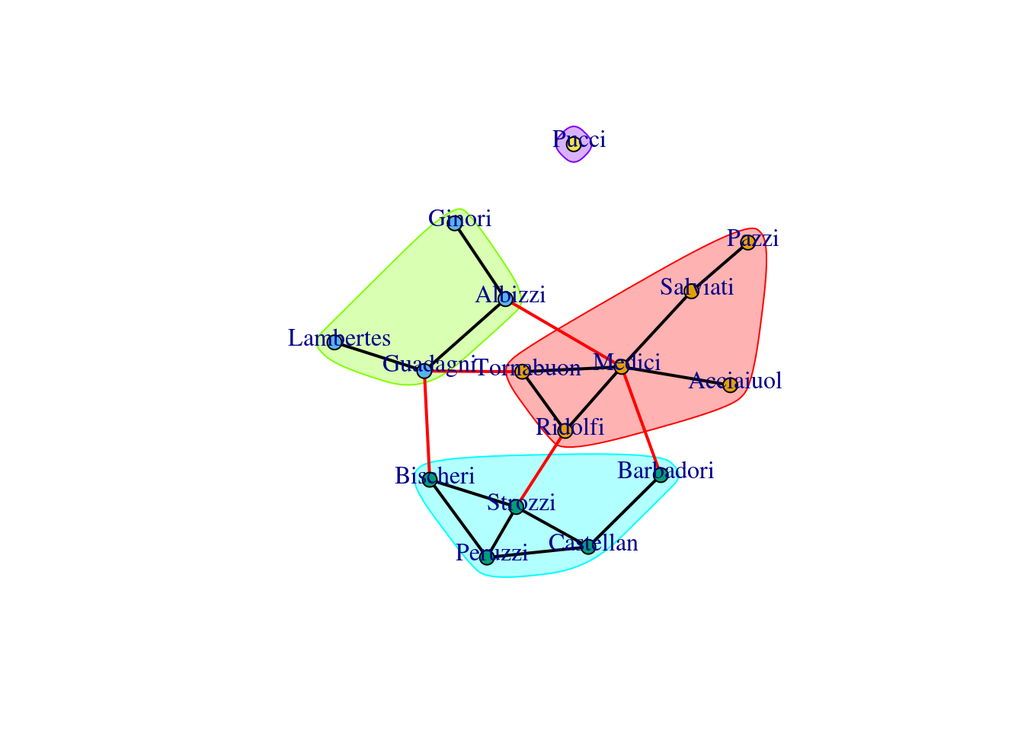

```r
plot(fgcommune, florentine)
```

- **Walktrap**: Подход, основанный на случайных путях. Основная идея – если случайно “блуждать” по графу, то больше шансов, что ваш путь будет чаще оставаться внутри сообщества и только иногда выходить за его пределы.

```r
wtcommune <- walktrap.community(florentine)
membership(wtcommune) ## assigning nodes to communities
```

```
## Acciaiuol   Albizzi Barbadori  Bischeri Castellan    Ginori  Guadagni
##         2         1         3         3         3         1         1
## Lambertes    Medici     Pazzi   Peruzzi     Pucci   Ridolfi  Salviati
##         1         2         4         3         5         2         4
##   Strozzi Tornabuon
##         3         2
```

```r
modularity(wtcommune)
```

```
## [1] 0.3975
```

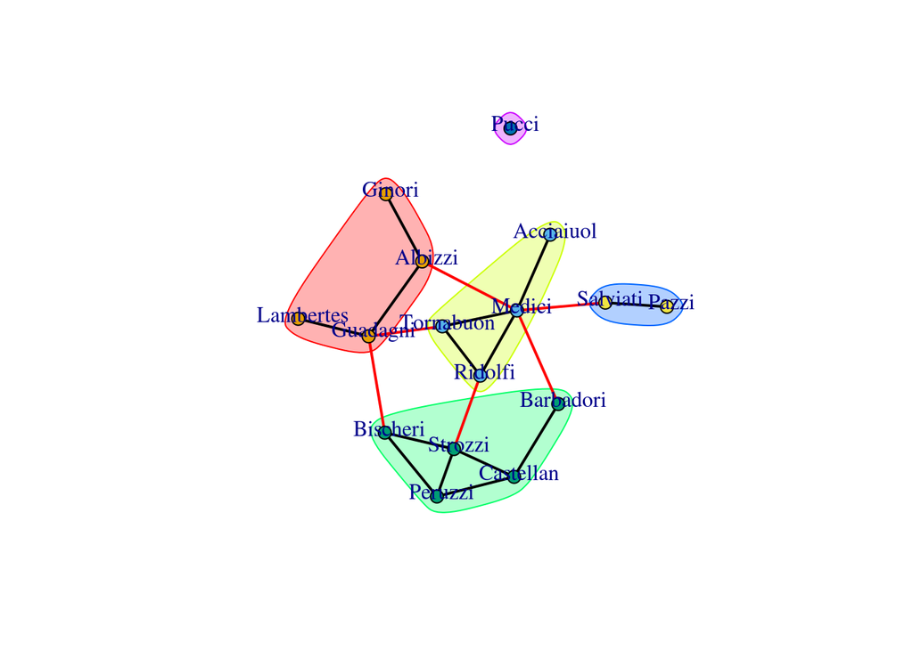

```r
plot(wtcommune, florentine)
```

Другие алгоритмы в `igraph` (см. справку)

- label.propagation.community
- leading.eigenvector.community
- multilevel.community
- optimal.community
- spinglass.community
- infomap.community

**Ваша очередь:**

- *Обратите внимание:* если вы уже создавали свою сеть, то у вас есть файл ~/graph_info.RData. В нем хранятся данные о вашей сети, собранные из ВК, и код сначала проверяет, есть ли такой файл. Поэтому когда вы будете собирать html (кнопка knit), не нужно будет опять ждать окончания скачивания данных.

Исследуйте свою сеть. Какие выводы вы можете сделать?

## Не только описание

Загрузите данные о переписке в небольшой IT-компании, проводящей маркетинговые исследования на R. Данные содержат матрицу 17х17 с направленными связями.

- help_seeking.csv – связь A->B в сети означает, что A отправил запрос B с просьбой проверить код на адекватность, чтобы позднее отправить заказчику.

```r
help_seeking <- read.csv("~/shared/minor2_2018/2-tm-net/lab02-centrality-community/help_seeking.csv")
```

Мы можем провести анализ и для этой сети – посчитать центральности и найти важные вершины, выделить сообщества. Но можно ли узнать что-то еще?

### Ассортативность

Для исследования структурных свойств сетей также можно оценить показатель **ассортативности или гомофилии**, т.е. того, насколько узлы склонны иметь связи с узлами, обладающими сходными свойствами. В этом случае мы уже добавляем в анализ не только сетевые, структурные характеристики (степень, битвинность и т.д.), но и какие-то внешние атрибуты (например, принадлежность к группе)

```r
library(igraph)
```

Преобразуем сети в igraph объекты

- как из матриц смежности можно получить объекты igraph?

Дополнительно загрузим файл с атрибутами узлов – attr, включающем имя (name), пол (sex), образование (education), уровень экспертизы (предположим, что знание R сотрудниками компании было зафиксировано и выражено в численной переменной expertise).

```r
g_help_seeking = graph_from_adjacency_matrix(as.matrix(help_seeking))
attr = read.csv("~/shared/minor2_2018/2-tm-net/lab02-centrality-community/attr.csv")
```

Добавим атрибуты к узлам сети

```r
V(g_help_seeking)$expertise = ifelse(V(g_help_seeking)$name %in% attr$name, attr$expertise, 0)
V(g_help_seeking)$expertise
```

```
##  [1] 0.17647059 0.17647059 0.17647059 0.52941176 0.52941176 0.58823529
##  [7] 0.05882353 0.29411765 0.58823529 0.05882353 0.17647059 0.05882353
## [13] 0.05882353 0.35294118 0.23529412 0.58823529 0.41176471
```

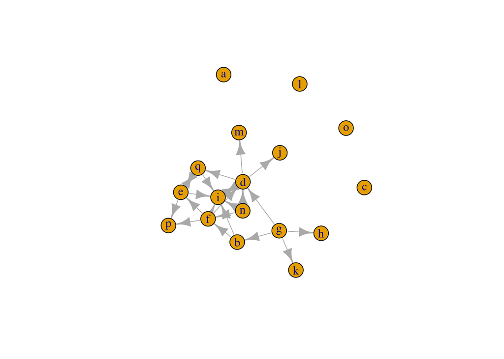

```r
plot(g_help_seeking)
```

Посчитаем коэффициент ассортативности

```r
assortativity(g_help_seeking, V(g_help_seeking)$expertise, directed = T)
```

```
## [1] 0.2262602
```

Итак, мы получили коэффициент ассортативности. Он измеряется от -1 до 1, где -1 – связи в сети склонны формироваться между узлами с отличающимися характеристиками, а 1 – узлы предпочитают формировать связь с похожими узлами (в нашем случае, похожие по уровню знания R), 0 – связи формируются без привязки к этой характеристике

Также можем посчитать ассортативность для категориальной переменной (обратите внимание на название функции)

```r
attr_sex = ifelse(V(g_help_seeking)$name %in% attr$name, attr$sex, 0)
levels(attr_sex) = c(1, 0)

V(g_help_seeking)$sex = attr_sex
assortativity_nominal(g_help_seeking, V(g_help_seeking)$sex, directed = T)
```

```
## [1] -0.02985075
```

- какие выводы можно сделать?

**Ваша очередь**

Рассмотрим еще одну сеть про сотрудников ИТ-компании

- feedback.csv – в этой сети связь B->A означает, что B ответил и оставил рецензию на код A.

```r
feedback <- read.csv("~/shared/minor2_2018/2-tm-net/lab02-centrality-community/feedback.csv")
```

Посмотрите, насколько работники склонны просить рецензии у “равных” по уровню образования